# yumCoffee

This is a project I decided to take on after I finished my first statistical computing class. (Obviously, I was on a coding high.) In this project, I collected my own tasting profile for coffee and decided to plot my patterns. It’s funny because as I did this plotting project and as I continue, I can see some obvious patterns that I actually didn’t notice of myself.

# Libraries

I used the following libraries to visualize these data.

```r
# LIBRARIES
library(stringr)
library(ggplot2)
library(ggrepel)
```

# Loading in Taste Profile

I recorded all of my preferences for all coffees that I have tried. Right now, I’m still getting through two whole bean bags of Peet’s coffee, so I won’t be able to add in new data for a while.

```r
my_coffee = read.csv("/Users/edie/Box Sync/GitThings/https---github.com-palautatan-yumCoffee.git/datasets/coffee_list.csv", header=TRUE)
attach(my_coffee)
head(my_coffee)
```

```
##       Date                          Coffee        Roast Personal.Rating
## 1   9/1/16        Folger's: Instant Coffee       Medium           0.5/5
## 2  9/12/16 Taster's Choice: Instant Coffee Medium-Light             0/5
## 3 10/14/16         Seattle's Best: Level 4  Medium-Dark           3.0/5
## 4 10/26/16     Joe: Tall Dark and Handsome         Dark           4.0/5
## 5 10/26/16    Hawaiian Gold: Original Kona       Medium           2.0/5
## 6  12/8/16              Starbucks: Veranda        Light           3.0/5
##     Store Fixtures..N.A.if.rating.is.for.black.
## 1  Costco                        Creamer, Sugar
## 2  Costco                        Creamer, Sugar
## 3  Target                                   N/A
## 4  TJMaxx                                   N/A
## 5  TJMaxx                                   N/A
## 6 Safeway                                   N/A
##                                                                                   Notes
## 1                                  Tastes better than Taster's Choice, but still shoddy
## 2                                                                 Tastes like chemicals
## 3                                                              Strong flavor, big aroma
## 4                                            My favorite coffee yet, strong dark flavor
## 5                                        Varies in flavor, sometimes acidic, shy flavor
## 6 A lot better than I expected; no awful acidic aftertaste, stronger flavor than stated
```

# Parsing Data

### Create New Dataframe

```r
# CREATE NEW DATA FRAME
updated_coffee = cbind(my_coffee, Rating, coffee_name[1,], coffee_name[2,])
names(updated_coffee)[9:10] = c("Brand", "Name")
attach(updated_coffee)
Roast = factor(Roast, levels=c("Special", "Light", "Medium-Light", "Medium", "French", "Medium-Dark", "Dark"))
```

# Plotting Preferences

Here’s a plot of the coffees I have had according to roast. In this plot “Special” means that the coffee was not black.

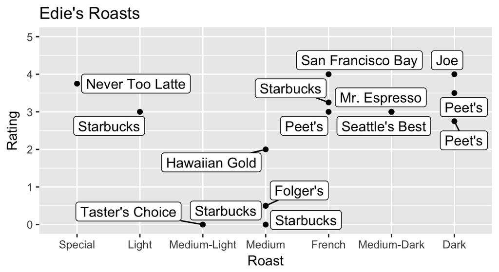

```r
# PLOTTING ROASTS
coffee_plot = ggplot()
coffee_plot = coffee_plot + geom_point(aes(x=Roast, y=Rating)) + geom_label_repel(aes(x=Roast, y=Rating, label=Brand)) + ylim(0,5)
coffee_plot = coffee_plot + ggtitle("Edie's Roasts")
coffee_plot
```

Here’s a plot of where I bought my coffee. The overlapping text in the plot is annoying, yes, but I think it’s legible enough. If you cannot read what the first three labels say, here you go: “Costco”, “Never Too Latte”, and “Ross”.

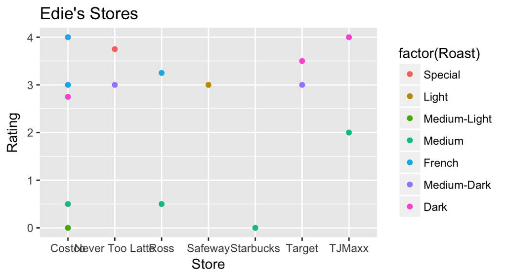

```r
# PLOTTING STORES
coffee_plot_2 = ggplot()
coffee_plot_2 = coffee_plot_2 + geom_point(aes(x=Store, y=Rating, colour=factor(Roast)))
coffee_plot_2 = coffee_plot_2 + ggtitle("Edie's Stores")
coffee_plot_2
```

# Analyzing Taste Profile

### Favorite Store

Apparently, my favorite store to buy coffee is Costco. I’m not surprised, and I’m glad my membership is doing me some good.

```r
# What is this taster's favorite store? (Most frequented)
table_store = rbind(levels(Store), table(Store))
fave_store = table_store[1,which(table_store[2,]==max(table_store[2,]))]
cat("This taster frequently goes to:", fave_store)
```

```
## This taster frequently goes to: Costco
```

```r
fave_store
```

```
##   Costco
## "Costco"
```

### Mean Tasting Score

My average tasting score is 2.42. I don’t think this makes me a coffee prude, nor does it justify my taste profile. I think it means that I really hate Instant Coffee, and several 0’s brought down my mean score a lot.

```r
# What is this taster's average score?
avg_score = mean(Rating)
avg_score
```

```
## [1] 2.416667
```

### Favorite Roast

```r
# What is this taster's favorite roast?
df_roast = sapply(levels(Roast), function(this_level) {
  these_rows = as.numeric(which(Roast==this_level))
  stat = mean(Rating[these_rows])
  c(this_level, stat)
}
)
fave_roast = df_roast[1,which(df_roast[2,]==max(df_roast[2,]))]
fave_roast
```

```
##   Special
## "Special"
```

### Top 3 Coffees

This says that my favorite coffees ever have been San Francisco Bay French Roast OneCup, Joe’s Tall Dark and Handsome, and the Pistachio Mocha Latte from Never Too Latte. I think that these are good estimates for my favorites, although I am not actually that much of a fan of super sugary drinks unless they’re boba drinks. So, in further analyses, I would probably do analyses on “Special” drinks and black coffee in different sections.

```r
# How about top 3 coffees?
# This takes the first 3 sorted regardless of ties
ratings_coffees = rbind(Rating, Name)
ratings_coffees = ratings_coffees[,order(Rating)]
indices = length(ratings_coffees[1,])-c(0:2)
top_three = levels(Name)[ratings_coffees[2, indices]]
top_three
```

```
## [1] "French Roast OneCup"    "Tall Dark and Handsome"
## [3] "Pistachio Mocha Latte"
```

Hope you enjoyed! This project is still being worked on every now and then, so come back for more, ’cause yum, coffee!